# STP598sta: Spatiotemporal Analysis

Point-referenced Models and Areal Models

Shiwei Lan

Fall 2020

## R Resources

We use `R` http://cran.r-project.org/ for some demos in this lecture. `RStudio` http://www.rstudio.com is also recommended. Actually, this html demo is written RStudio using `RMarkdown`.

## Point-referenced Models

In lecture 1, we have learned point-referenced data models. Let’s look at some examples. More specifically, we will use `R` to show **EDA**, **variogram** and **kriging**. To do that, we need R package called `geoR`. Let’s install it.

```r
install.packages('geoR')
```

After we install it, we load it.

```r
library('geoR')
```

Ok, now we are ready for some exploratory data analysis (EDA).

### EDA

Let’s first look at the scallops data, which give the locations and scallop catches in the Atlantic waters off the coasts of New Jersey and Long Island, New York.

```r
myscallops<-read.table('https://www.counterpointstat.com/uploads/1/1/9/3/119383887/myscallops.txt',header=T)
```

If the link fails, try to download it from the course website. Now we plot the locations on the map.

```r
install.packages('maps')
```

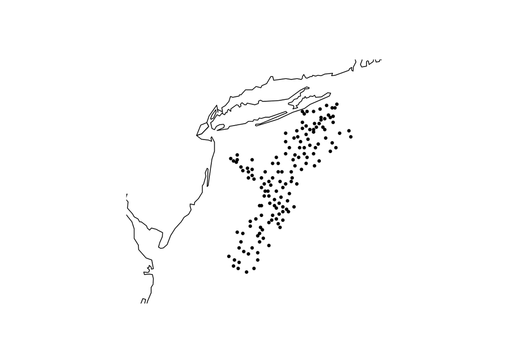

```r
library(maps)
map('usa',xlim=c(-75.5,-71),ylim=c(38.2,41.5))
points(myscallops$long,myscallops$lat,pch=20,cex=0.75)
```

```r
install.packages('akima')
```

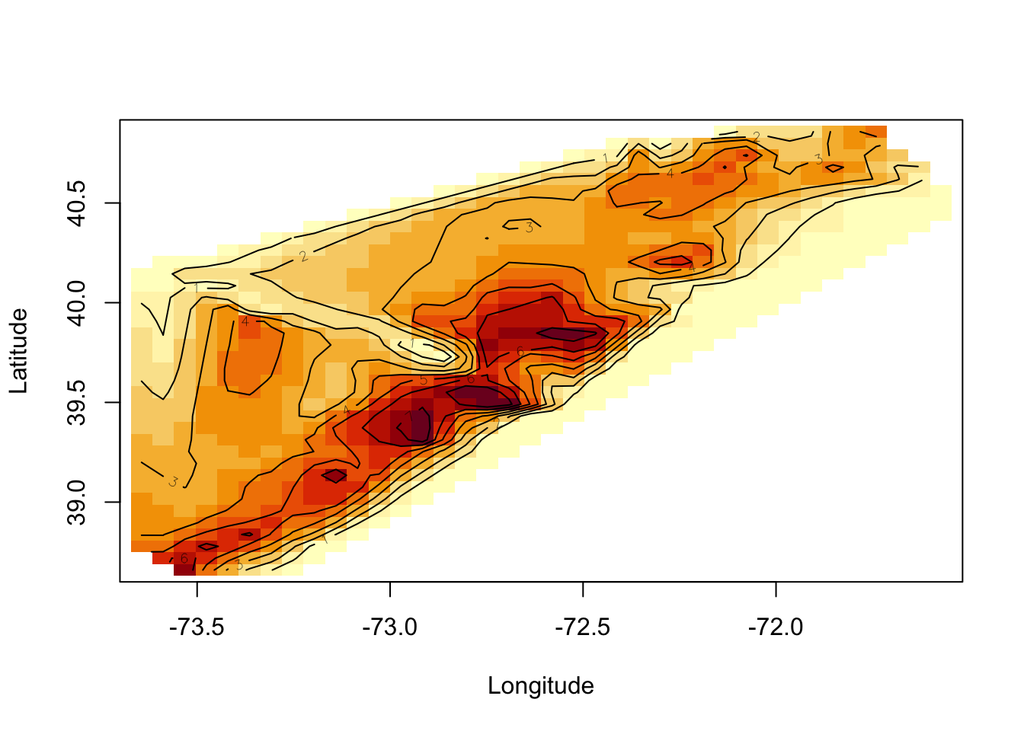

```r
library(akima)
int.scp = interp(myscallops$long,myscallops$lat,myscallops$lgcatch,extrap=T)
image(int.scp,xlim=range(myscallops$long),ylim=range(myscallops$lat),xlab='Longitude',ylab='Latitude')
contour(int.scp,add=T)
```

Another useful tool is the 3d surface plot by `persp` function:

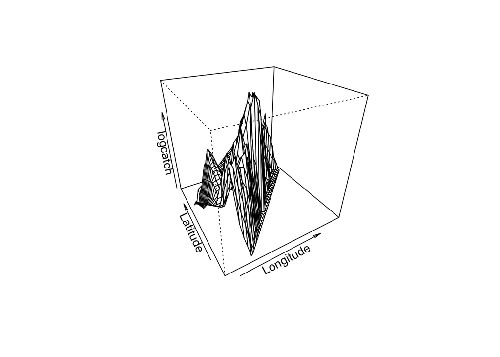

```r
persp(int.scp,theta = -30, phi = 30,xlim=range(myscallops$long),ylim=range(myscallops$lat),xlab='Longitude',ylab='Latitude',zlab='logcatch')
```

### variograms

Now we estimate variograms. We will use `variog` function from `geoR` package. This function takes `geodata` object as in put, which can be created using `as.geodata` function.

```r
obj = cbind(myscallops$long,myscallops$lat,myscallops$lgcatch)
scallops.geo=as.geodata(obj,coords.col = 1:2,data.col = 3)
```

Now, a variogram object is created using `variog` function. And the robust estimator can be obtained by using ‘modulus’ type in `variog` function.

```r
scallops.var=variog(scallops.geo,estimator.type='classical')
```

```
## variog: computing omnidirectional variogram
```

```r
# scallops.var
scallops.var.robust=variog(scallops.geo,estimator.type='modulus')
```

```
## variog: computing omnidirectional variogram
```

We can plot them together

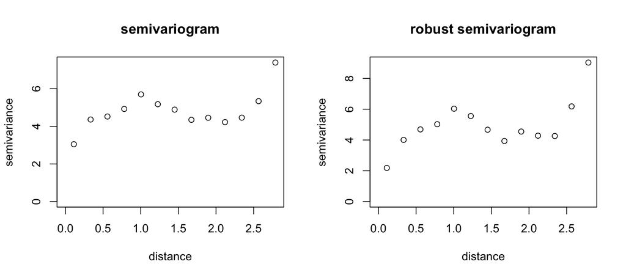

```r
par(mfrow=c(1,2))
plot(scallops.var)
title('semivariogram')
plot(scallops.var.robust)
title('robust semivariogram')
```

Followingly, we use `variofit` function from `geoR` to estimate the sill, the range, and the nugget parameters under a specific covariance model. We can specify the covariance model by `cov.model` option.

```r
scallops.var.fit=variofit(scallops.var.robust, ini.cov.pars=c(2.0,.5),cov.model='exponential',fix.nugget = F,nugget = 1.0)
```

```
## variofit: covariance model used is exponential
## variofit: weights used: npairs
## variofit: minimisation function used: optim
```

```r
print(scallops.var.fit)
```

```
## variofit: model parameters estimated by WLS (weighted least squares):
## covariance model is: exponential
## parameter estimates:
##   tausq sigmasq     phi
##  0.0000  5.1110  0.2065
## Practical Range with cor=0.05 for asymptotic range: 0.6184934
##
## variofit: minimised weighted sum of squares = 4017.547
```

```r
scallops.lik.fit=likfit(scallops.geo, ini.cov.pars = c(2.0,.5),cov.model='exponential',trend='cte',fix.nugget = F,nugget = 1.0,nospatial=T,lik.method='ML')
```

```
## kappa not used for the exponential correlation function
## ---------------------------------------------------------------
## likfit: likelihood maximisation using the function optim.
## likfit: Use control() to pass additional
##          arguments for the maximisation function.
##         For further details see documentation for optim.
## likfit: It is highly advisable to run this function several
##         times with different initial values for the parameters.
## likfit: WARNING: This step can be time demanding!
## ---------------------------------------------------------------
## likfit: end of numerical maximisation.
```

```r
print(scallops.lik.fit)
```

```
## likfit: estimated model parameters:
##     beta    tausq  sigmasq      phi
## "2.3748" "0.0947" "5.7676" "0.2338"
## Practical Range with cor=0.05 for asymptotic range: 0.70055
##
## likfit: maximised log-likelihood = -285.9
```

where `trend="cte"` means a spatial regression model with constant mean. The estimated result is 2.3747786.

### kriging

There are two built-in functions in `geoR` for kriging: `krige.conv` is for convential kriging; `krige.bayes` performs Bayesian kriging. Note, `krige.bayes` is limited to fitting a spatial regression model with constant mean, an exponential covariance model, a flat prior for the constant trend level, the reciprocal (Jeffrey’s) prior for the sill, and a discrete uniform prior for the nugget.

```r
scallops.bayes = krige.bayes(scallops.geo,locations = 'no',borders = NULL, model = model.control(trend.d='cte',cov.model = 'exponential'),prior = prior.control(beta.prior = 'flat',sigmasq.prior = 'reciprocal',tausq.rel.prior ='uniform', tausq.rel.discrete = seq(0,1,.01) ))
```

We obtain samples for the mean, the sill, the range, and the nugget.

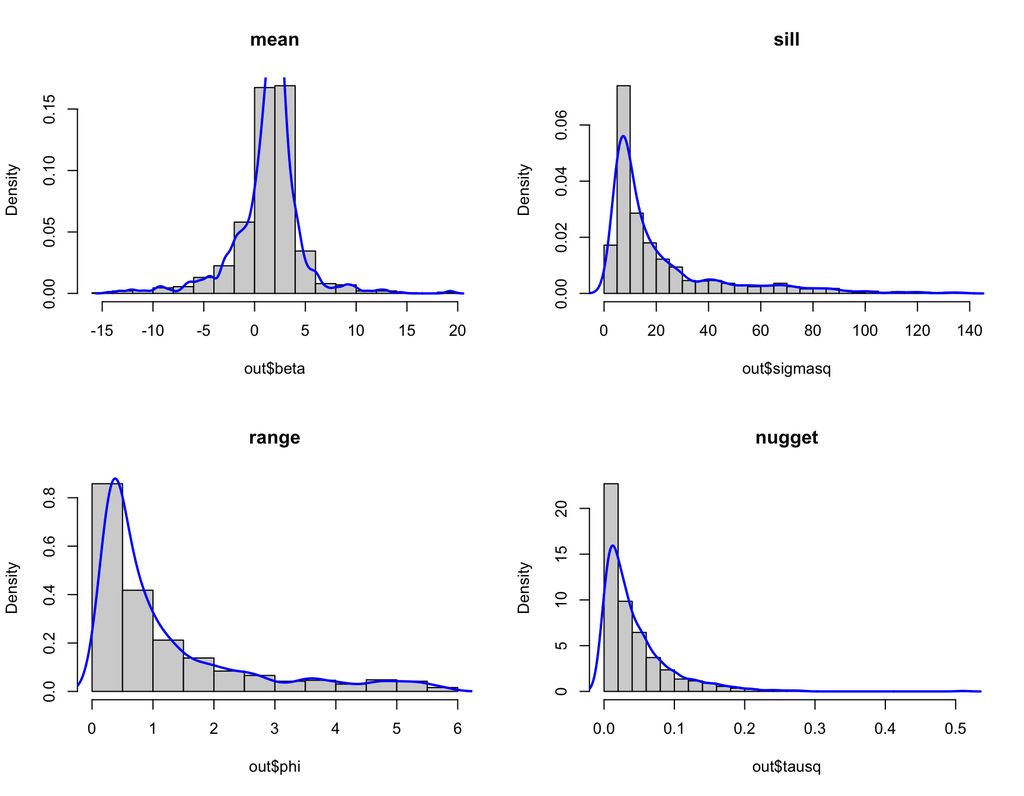

```r
out=scallops.bayes$posterior$sample
par(mfrow=c(2,2))
hist(out$beta,breaks=20,freq=F,main=NULL)
lines(density(out$beta),col='blue',lwd=2)
title('mean')
hist(out$sigmasq,breaks=20,freq=F,main=NULL)
lines(density(out$sigmasq),col='blue',lwd=2)
title('sill')
hist(out$phi,breaks=20,freq=F,main=NULL)
lines(density(out$phi),col='blue',lwd=2)
title('range')
hist(out$tausq,breaks=20,freq=F,main=NULL)
lines(density(out$tausq),col='blue',lwd=2)
title('nugget')
```

## Areal Models

In this section, we use some `R` function to obtain proximity matrix, compute Moran’s and Geary’s statistics and fit CAR and SAR models. We will the `R` package named `spdep`. Let’s first install and load it.

```r
install.packages('spdep')
install.packages('maptools')
install.packages('RColorBrewer')
```

```r
library(spdep)
library(maptools)
library(classInt)
library(RColorBrewer)
```

First, let’s compute the proximity (adjacency) matrix of US states.

```r
usa.state=map(database="state", fill=TRUE, plot=FALSE)
state.ID <- sapply(strsplit(usa.state$names, ":"), function(x) x[1])
usa.poly = map2SpatialPolygons(usa.state, IDs=state.ID)
usa.nb = poly2nb(usa.poly)
usa.adj.mat = nb2mat(usa.nb, style="B")
```

Constructing adjacency matrices for counties in a U.S. state is a little different because of the naming convention in `map`. Now let’s take Minnesota for example.

```r
mn.county = map("county", "minnesota", fill=TRUE, plot=FALSE)
county.ID <- sapply(strsplit(mn.county$names, ","), function(x) x[2])
mn.poly = map2SpatialPolygons(mn.county, IDs=county.ID)
mn.nb = poly2nb(mn.poly)
mn.adj.mat = nb2mat(mn.nb, style="B")
```

One can easily retrieve neighbors of a country. Let’s obtain neighbors of `Winona` county in Minnesota.

```r
mn.region.id <- attr(mn.nb, "region.id")
winona.neighbors.index = mn.nb[[match("winona", mn.region.id)]]
winona.neighbors = rownames(mn.adj.mat[winona.neighbors.index,])
print(winona.neighbors)
```

```
## [1] "fillmore" "houston"  "olmsted"  "wabasha"
```

### Moran’s I and Geary’s C

Now we can use `moran.test` and `geary.test` functions in the `spdep` package to obtain Moran’s I and Geary’s C statistics. Let’s use the SAT scores data for illustration. First we need to convert `usa.nb` to a `listw` object in `R`.

```r
usa.listw = nb2listw(usa.nb, style="W")
state.sat.scores<-read.table('https://www.counterpointstat.com/uploads/1/1/9/3/119383887/state-sat.dat',header=F)
colnames(state.sat.scores) <- c('STATE','VERBAL','MATH','PERCT')
# remove alaska and hawaii
x = ((state.sat.scores$STATE=="alaska") | (state.sat.scores$STATE=="hawaii") | (state.sat.scores$STATE=="us"))
index = c(1:nrow(state.sat.scores))[x]
state.sat.scores.contig = state.sat.scores[-index,]
```

Next we use `moran.test` function to obtain

```r
moran.out=moran.test(state.sat.scores.contig$VERBAL, listw=usa.listw)
moran.I = moran.out$estimate[1]
moran.I.se = sqrt(moran.out$estimate[3])
moran_tab=data.frame(I=moran.I, se=moran.I.se)
table(moran_tab)
```

```
##                    se
## I                   0.0978842420863728
##   0.612539264360041                  1
```

Geary’s C can be computed analogously using the `geary.test` function

```r
geary.out=geary.test(state.sat.scores.contig$VERBAL, listw=usa.listw)
geary.C = geary.out$estimate[1]
geary.C.se = sqrt(geary.out$estimate[3])
geary_tab=data.frame(C=geary.C, se=geary.C.se)
table(geary_tab)
```

```
##                    se
## C                   0.0983737901628913
##   0.357738128288517                  1
```

### SAR and CAR model fitting

Now we fit spatial autoregression models using available functions in the `spdep` package.

- **SIDS**

A convenient illustration is offered by the `SIDS (sudden infant death syndrome)`, loaded into the `spdep` package. This dataset contains counts of SIDS deaths from 1974 to 1978 and counts from 1979 to 1983 along with related covariate information for the 100 counties in the U.S. State of North Carolina. The dataset can be read from a shapefile `sids.shp` and an `nb` object can be constructed from a GAL file `ncCC89` included in `spdep`.

```r
nc.sids <- readShapePoly(system.file("shapes/sids.shp", package="spData")[1],ID="FIPSNO", proj4string=CRS("+proj=longlat +ellps=clrk66"))
rn <- sapply(slot(nc.sids, "polygons"), function(x) slot(x, "ID"))
ncCC89.nb <- read.gal(system.file("weights/ncCC89.gal", package="spData")[1], region.id=rn)
```

The first step produces a `SpatialPolygonsDataFrame` object `nc.sids`, while the second step produces the region IDs and stores them in `rn`. The third step uses these region IDs to produce an `nb` object by directly reading from the GAL file.

We next use a Freeman-Tukey transformation to produce the **transformed rates** and append them to the `nc.sids` object.

```r
nc.sids.rates.FT = sqrt(1000) * (sqrt(nc.sids$SID79/nc.sids$BIR79) + sqrt((nc.sids$SID79 + 1)/nc.sids$BIR79))
nc.sids$rates.FT = nc.sids.rates.FT
```

We wish to regress these rates on the **non-white birth rates** over the same period. This variable is available as `NWBIR79` in the `nc.sids` object. We will use the Freeman-Tukey transformed birth rates

```r
nc.sids.nwbir.FT = sqrt(1000) * (sqrt(nc.sids$NWBIR79/nc.sids$BIR79) + sqrt((nc.sids$NWBIR79 + 1)/nc.sids$BIR79))
nc.sids$nwbir.FT = nc.sids.nwbir.FT
```

Maximum likelihood estimation can be carried out using the `errorsarlm` or `spautolm` function in `spdep`. First, we fit a SAR model.

```r
# prepare for adjacency matrix
ncCC89.listw = nb2listw(ncCC89.nb, style="B", zero.policy=TRUE) # zero.policy=TRUE because of two islands
# nc.county.id = attr(ncCC89.nb, "region.id")
# nc.no.neighbors = card(ncCC89.nb)
# nc.islands = as.character(nc.sids[card(ncCC89.nb) == 0, ]$NAME)
# print(nc.islands)
# fit SAR model
#nc.sids.sar.out = errorsarlm(rates.FT~ nwbir.FT, data=nc.sids, listw=ncCC89.listw, zero.policy=TRUE)
nc.sids.sar.out = spautolm(rates.FT~ nwbir.FT, data=nc.sids, family="SAR", listw=ncCC89.listw, zero.policy=TRUE)
summary(nc.sids.sar.out)
```

```
##
## Call: spautolm(formula = rates.FT ~ nwbir.FT, data = nc.sids, listw = ncCC89.listw,     family = "SAR", zero.policy = TRUE)
##
## Residuals:
##       Min        1Q    Median        3Q       Max
## -2.266049 -0.428139  0.004331  0.497818  2.516498
##
## Regions with no neighbours included:
##  37055 37095
##
## Coefficients:
##              Estimate Std. Error z value Pr(>|z|)
## (Intercept) 2.5216462  0.2570334  9.8106  < 2e-16
## nwbir.FT    0.0124001  0.0071867  1.7254  0.08445
##
## Lambda: 0.05206 LR test value: 2.218 p-value: 0.13641
## Numerical Hessian standard error of lambda: 0.033692
##
## Log likelihood: -123.6898
## ML residual variance (sigma squared): 0.68697, (sigma: 0.82883)
## Number of observations: 100
## Number of parameters estimated: 4
## AIC: 255.38
```

```r
nc.sids$fitted.sar = fitted(nc.sids.sar.out)
```

Then, we fit a CAR model.

```r
# fit CAR model
nc.sids.car.out = spautolm(rates.FT~ nwbir.FT, data=nc.sids, family="CAR", listw=ncCC89.listw, zero.policy=TRUE)
summary(nc.sids.car.out)
```

```
##
## Call: spautolm(formula = rates.FT ~ nwbir.FT, data = nc.sids, listw = ncCC89.listw,     family = "CAR", zero.policy = TRUE)
##
## Residuals:
##       Min        1Q    Median        3Q       Max
## -2.202149 -0.408797  0.022183  0.459177  2.590967
##
## Regions with no neighbours included:
##  37055 37095
##
## Coefficients:
##              Estimate Std. Error z value Pr(>|z|)
## (Intercept) 2.5148477  0.2584345  9.7311  < 2e-16
## nwbir.FT    0.0126925  0.0072129  1.7597  0.07846
##
## Lambda: 0.094278 LR test value: 2.1267 p-value: 0.14475
## Numerical Hessian standard error of lambda: 0.057067
##
## Log likelihood: -123.7354
## ML residual variance (sigma squared): 0.68151, (sigma: 0.82554)
## Number of observations: 100
## Number of parameters estimated: 4
## AIC: 255.47
```

```r
nc.sids$fitted.car = fitted(nc.sids.car.out)
```

Once the estimates from the model have been obtained, we may wish to plot the fitted rates and compare them with the raw data.

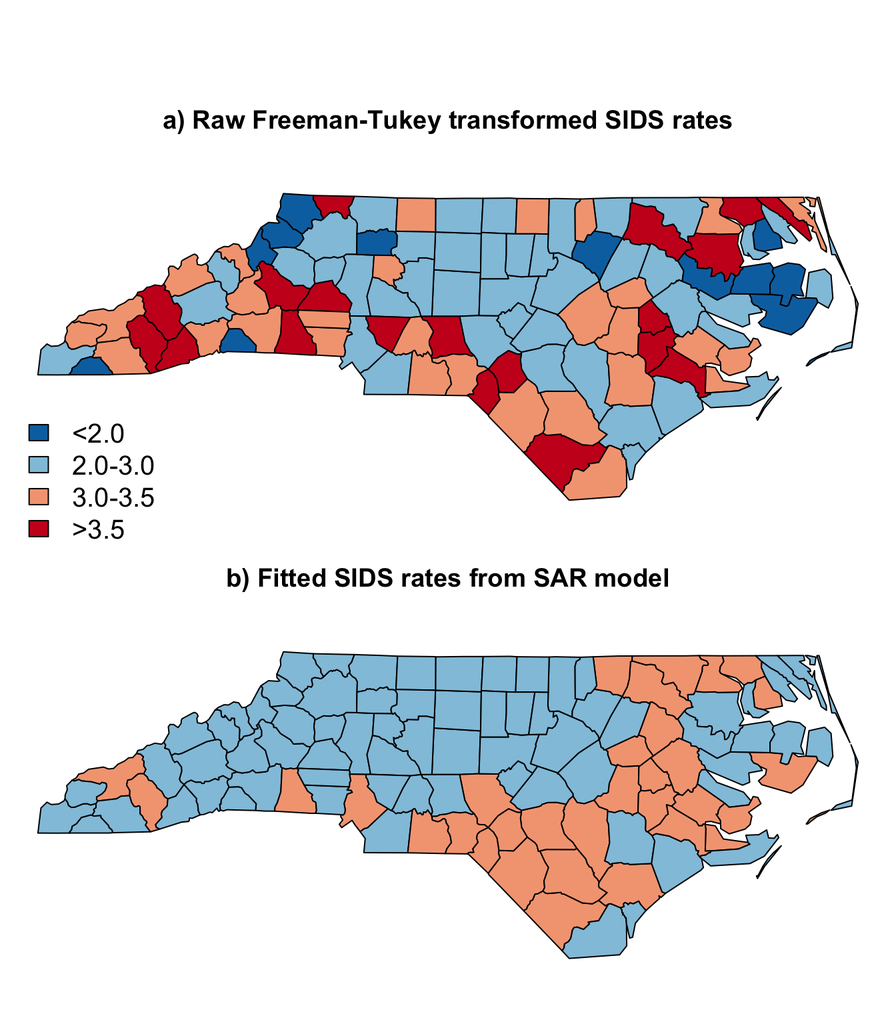

```r
#Draw the maps using the maps function
library(maps)
library(classInt)
brks = c(0, 2.0, 3.0, 3.5, 6.0)
color.pallete = rev(brewer.pal(4,"RdBu"))
class.raw = classIntervals(var=nc.sids$rates.FT, n=4, style="fixed", fixedBreaks=brks, dataPrecision=4)
color.code.raw = findColours(class.raw, color.pallete)
class.fitted = classIntervals(var=nc.sids$fitted.sar, n=4, style="fixed", fixedBreaks=brks, dataPrecision=4)
color.code.fitted = findColours(class.fitted, color.pallete)

leg.txt = c("<2.0", "2.0-3.0", "3.0-3.5",">3.5")

par(mfrow=c(2,1), oma = c(0,0,4,0) + 0.1, mar = c(0,0,1,0) + 0.1)
plot(nc.sids, col=color.code.raw)
title("a) Raw Freeman-Tukey transformed SIDS rates" )
legend("bottomleft", legend=leg.txt, cex=1.25, bty="n", horiz = FALSE, fill = color.pallete)
plot(nc.sids, col=color.code.fitted)
title("b) Fitted SIDS rates from SAR model")
```

- **Columbus**

So far, we have fit SAR and CAR models based on adjacency matrices. In the following, we are going to build SAR and CAR models using distance. For this purpose, we consider a different data set called `Columbus`, available in the `spdep` package. This data set offers neighborhood-level information on crime, mean home value, mean income, and other variables for 49 neighborhoods in Columbus, OH, during 1980

Let’s first create a `SpatialPolygonsDataFrame` object by reading a Columbus shapefile.

```r
columbus.poly <- readShapePoly(system.file("shapes/columbus.shp", package="spData")[1])
```

To create a distance-based neighborhood object, we need `dnearneigh` function from `spdep`. To avoid ``islands", we refer to k-nearest neighbors.

```r
columbus.coords = coordinates(columbus.poly)
columbus.knn = knearneigh(columbus.coords)
columbus.knn2nb = knn2nb(columbus.knn)
columbus.dist.list = nbdists(columbus.knn2nb, columbus.coords)
columbus.dist.vec = unlist(columbus.dist.list)
columbus.dist.max = max(columbus.dist.vec)
columbus.dnn.nb = dnearneigh(columbus.coords, 0, columbus.dist.max)
```

And finally we form a distance-based proximity matrix (`listw` object) that can be used in `spautolm`.

```r
columbus.dnn.listw = nb2listw(columbus.dnn.nb, style="B", zero.policy=TRUE)
```

Now we are ready to build SAR and CAR models as before.

```r
##SAR model regressing HOUSE_VAL+INCOME using distance-based nearest neighbors
columbus.dnn.sar.out = spautolm(CRIME~HOVAL+INC, data=columbus.poly, family="SAR", listw=columbus.dnn.listw, zero.policy=TRUE)
columbus.dnn.sar.fitted = fitted(columbus.dnn.sar.out)
columbus.poly$fitted.dnn.sar = columbus.dnn.sar.fitted
summary(columbus.dnn.sar.out)
```

```
##
## Call: spautolm(formula = CRIME ~ HOVAL + INC, data = columbus.poly,     listw = columbus.dnn.listw, family = "SAR", zero.policy = TRUE)
##
## Residuals:
##       Min        1Q    Median        3Q       Max
## -31.18714  -4.18864  -0.24961   6.10122  22.69041
##
## Coefficients:
##              Estimate Std. Error z value  Pr(>|z|)
## (Intercept) 50.229861   5.422987  9.2624 < 2.2e-16
## HOVAL       -0.251366   0.079881 -3.1468  0.001651
## INC         -0.826528   0.298414 -2.7697  0.005610
##
## Lambda: 0.11302 LR test value: 19.536 p-value: 9.8716e-06
## Numerical Hessian standard error of lambda: 0.011329
##
## Log likelihood: -177.6092
## ML residual variance (sigma squared): 73.306, (sigma: 8.5619)
## Number of observations: 49
## Number of parameters estimated: 5
## AIC: 365.22
```

```r
##CAR model regressing HOUSE_VAL+INCOME using distance-based nearest neighbors
columbus.dnn.car.out = spautolm(CRIME~HOVAL+INC, data=columbus.poly, family="CAR", listw=columbus.dnn.listw, zero.policy=TRUE)
columbus.dnn.car.fitted = fitted(columbus.dnn.car.out)
columbus.poly$fitted.dnn.car = columbus.dnn.car.fitted
summary(columbus.dnn.car.out)
```

```
##
## Call: spautolm(formula = CRIME ~ HOVAL + INC, data = columbus.poly,     listw = columbus.dnn.listw, family = "CAR", zero.policy = TRUE)
##
## Residuals:
##      Min       1Q   Median       3Q      Max
## -32.1557  -4.8140  -1.7260   4.3194  21.1322
##
## Coefficients:
##              Estimate Std. Error z value  Pr(>|z|)
## (Intercept) 49.563420   5.507341  8.9995 < 2.2e-16
## HOVAL       -0.245813   0.081797 -3.0052  0.002654
## INC         -0.832485   0.305032 -2.7292  0.006349
##
## Lambda: 0.12815 LR test value: 17.797 p-value: 2.4577e-05
## Numerical Hessian standard error of lambda: 0.0028054
##
## Log likelihood: -178.4787
## ML residual variance (sigma squared): 75.95, (sigma: 8.7149)
## Number of observations: 49
## Number of parameters estimated: 5
## AIC: 366.96
```